Link to colab: https://colab.research.google.com/drive/1M4jGm3w-6VrllJX7yLxu79TFyPjI37rs

Link to html version: https://raw.githack.com/michaeldybdahl/M2_miniassignements/master/Copy%20of%20m3_ass.html

# Loading packages

**Installing keras.**

I start by installing keras from the github remote.

```r
devtools::install_github("rstudio/keras")
```

[output not shown]

```
Installing 6 packages: reticulate, tensorflow, tfruns, R6, Rcpp, config
```

[output not shown]

Afterwards I load the packages including the keras package.

```r
library(keras)
library(dplyr)
library(ggplot2)
library(purrr)
library(tidyverse)
```

# Loading data

I load the data using the "read_csv" function.

```r
data <- read_csv("https://raw.githubusercontent.com/DeepLearnI/trump_tweet_classifier/master/code/tweet_labels.csv")
```

**Recoding the labels.**

The labels are coded with a TRUE og FALSE values (boolean format). I want to change this to 0 and 1 values (1 = TRUE).

Here I just assign the labels "as.integer", so the variable become numeric.

```r
data$labels <- as.integer(data$labels)
```

# 1. Recurrent Neural network (RNN) model

I am going to build a RNN model to classify if the tweet is a true or fake trump tweet.

I will the this in three steps:

1. Preprocess the data
2. Define the architecture & Compile the model
3. Run the model

After this I plot and evalutate the performance of the model.

## 1.1. Preprocessing

I start by assigning the tweets into a "text" variable. This is not strictly necessary, but I like to have the tweets into a separat variable.

```r
text <- data$tweet
```

First true step in the preprocess is to tokenize the text into tokens.

This could be done in several ways for example removing stopwords, creating a tidy format etc.

I have chosen just to use keras for the tokenizing, where I use "text_tokenizer from keras to do the job.

**max_features** is set to 10.000, so I only get the 10.000 most common words in the tweets. I tried other numbers, but 10k seemed to work best.

```r
max_features <- 10000
tokenizer <- text_tokenizer(num_words = max_features)
```

Now I fit the tokenizer to the text data, using "fit_text_tokenizer" from keras.

```r
tokenizer %>%
  fit_text_tokenizer(text)
```

Now I encode the tweets into sequences of indices by using "texts_to_sequences" from keras.

```r
text_seqs <- texts_to_sequences(tokenizer, text)
```

**Setting the parameters:**

I am going to use some parameters both for the preprocessing and fitting part.

I set the parameters, because I used several different input for the "maxlen", batch size and number of epochs to find the best model.

By setting the parameters, I dont have to change it inside the different parts, but can just change it here.

```r
# Set parameters:
maxlen <- 1000
batch_size <- 8
epochs <- 10
```

The sequences are going to be the x values and here I need to pad the sequences, so the all have the same length.

The max length was set to 1000, where I also tried several variations as 100-1000, but 1000 made the model perform best.

```r
x_train <- text_seqs %>%
  pad_sequences(maxlen = maxlen) # using pad_sequence for the padding and setting "maxlen" to the predefined parameter from above.
dim(x_train)
```

1. 15348

2. 1000

the y values for the training set will be the labels that define either it is a true or fake trump tweet.

We can see that the length is 15348, which was the total number of tweets.

```r
y_train <- data$labels
length(y_train)
```

15348

## 1.2. Define the architecture & compile the model

Now I define the architecture for the model, where I add the embeddings, shapes and layers.

I also use the pipe to compile the model with the loss, optimizer and metric.

```r
model <- keras_model_sequential() %>%
  layer_embedding(input_dim = 10000, output_dim = 32) %>% # input_dim 10000 because the vocabulary (max features), which I set to 10.000.
  layer_simple_rnn(units = 32, activation = "tanh") %>% # = the layer on top.
  layer_dense(units = 1, activation = "sigmoid") %>% # = output layer. -> units = 1, because we got a binary classification problem. I use "sigmoid" which is common for binary classification problems.
  layer_dropout(0.2) %>% compile( # I added a dropout layer because of overfitting problems.
  loss = "binary_crossentropy", # I use "binary_crossentropy" because I have abinary classification problem and the output of your network is a probability.
  optimizer = "adam", # I used "adam" as optimizer, which ran better than "rmsprop" - not sure why.
  metrics = "accuracy" # I use accuracy as metric because the response variable (TRUE/FAKE tweets) is balanced (8000 true vs. 7348 fake).
)
```

```r
summary(model)
```

```
Model: "sequential"
________________________________________________________________________________
Layer (type)                        Output Shape                    Param #
================================================================================
embedding (Embedding)               (None, None, 32)                320000
________________________________________________________________________________
simple_rnn (SimpleRNN)              (None, 32)                      2080
________________________________________________________________________________
dense (Dense)                       (None, 1)                       33
________________________________________________________________________________
dropout (Dropout)                   (None, 1)                       0
================================================================================
Total params: 322,113
Trainable params: 322,113
Non-trainable params: 0
________________________________________________________________________________
```

## 1.4. Running the model

Now I can fit and run the model using "fit" function from keras.

I first give the function the x and y values from the training set as arguments. After this I set the batch size and epochs based on the predefined parameters.

Batch size was set to 8, after having ran with higher sizes (up to 512), but this overfitted the model already after the 1st epoch.

```r
hist <- model %>%
  fit(
    x_train,
    y_train,
    batch_size = batch_size,
    epochs = epochs,
    validation_split = 0.1,
  )
```

## 1.5. Evaluating the model

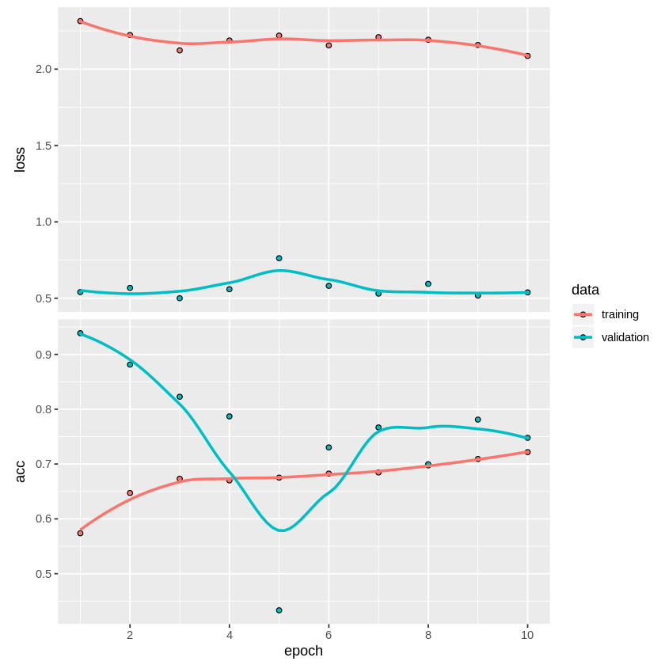

```r
plot(hist)
```

I look at the validation accuracy for each epoch.

```r
hist$metrics$val_acc
```

1. 0.938762187957764

2. 0.881433248519897

3. 0.822801291942596

4. 0.786970674991608

5. 0.433224767446518

6. 0.730293154716492

7. 0.766775250434875

10. 0.747882723808289

**Evaluation:**

There is probably some overfitting problems here because of the high val_acc in 1st epoch, but I couldt figure out solving this and ran out of time, sadly :-(

I also attempted LSTM and cudNN-LSTM, but the notebook just ran for hours without completing.

# 2. The end

[figure not shown]